# Take-Home Exercise 3: Prototyping Modules for Geospatial Analytics Shiny Application

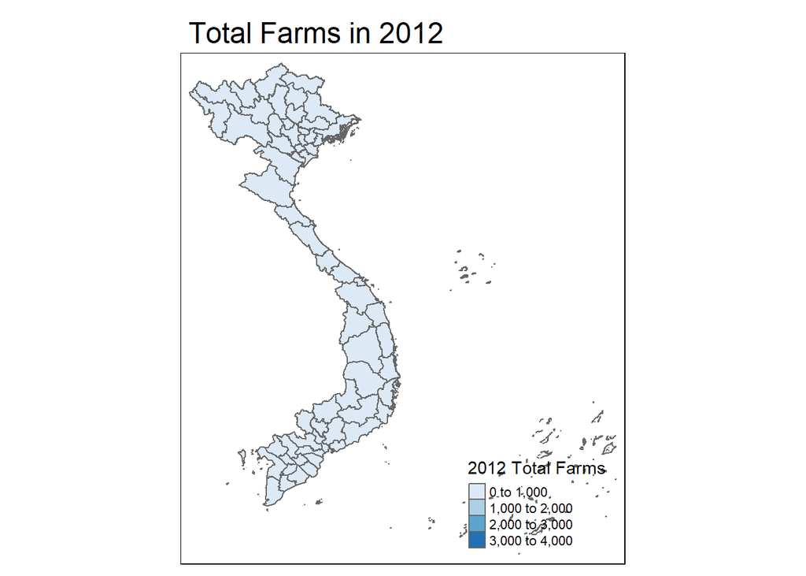

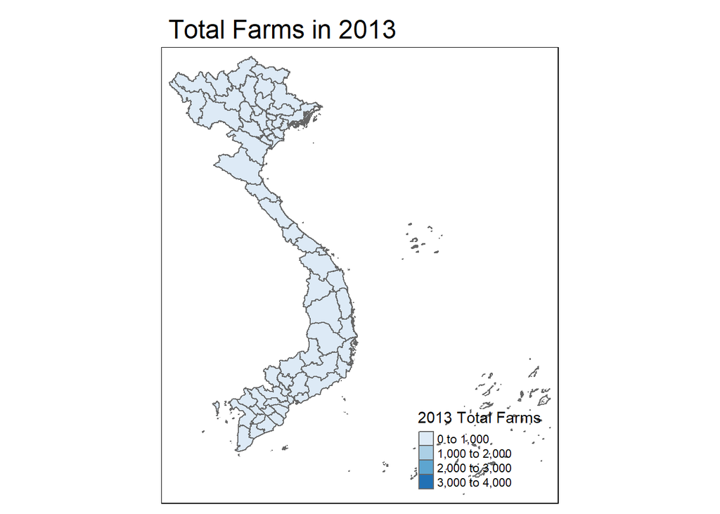

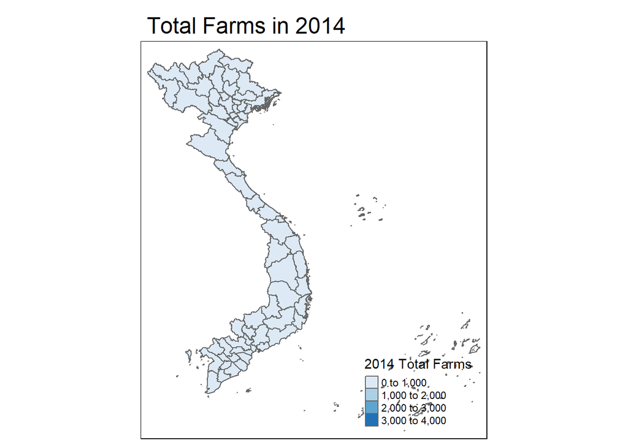

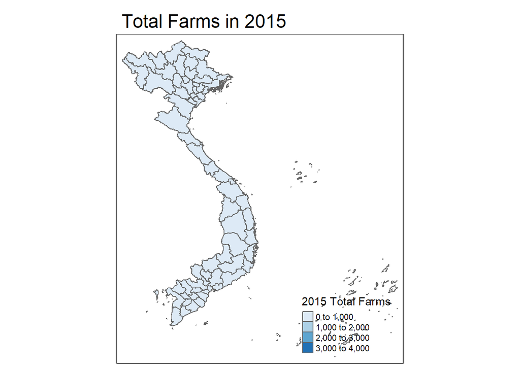

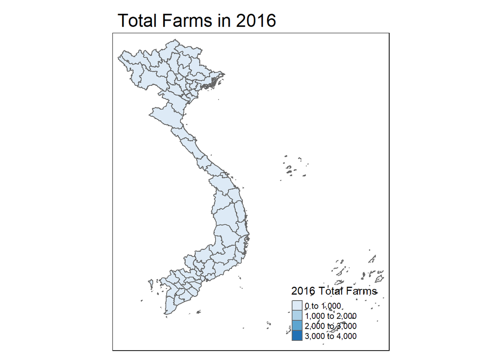

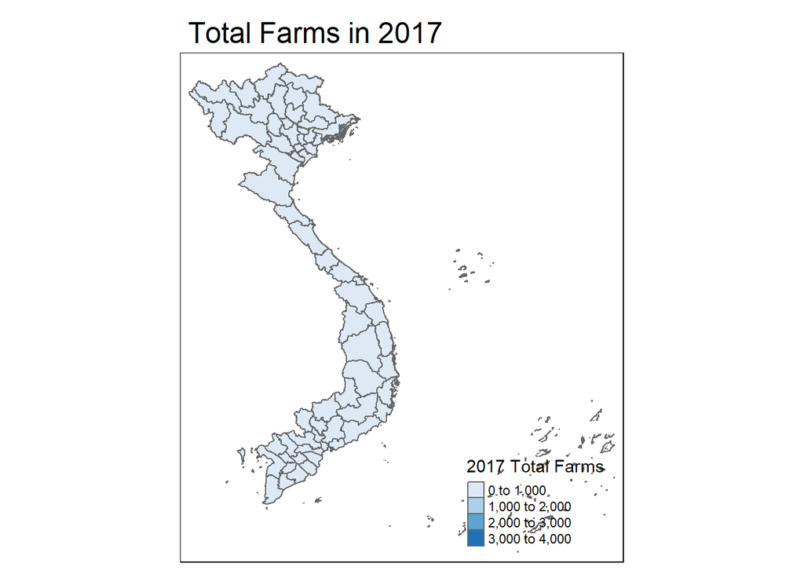

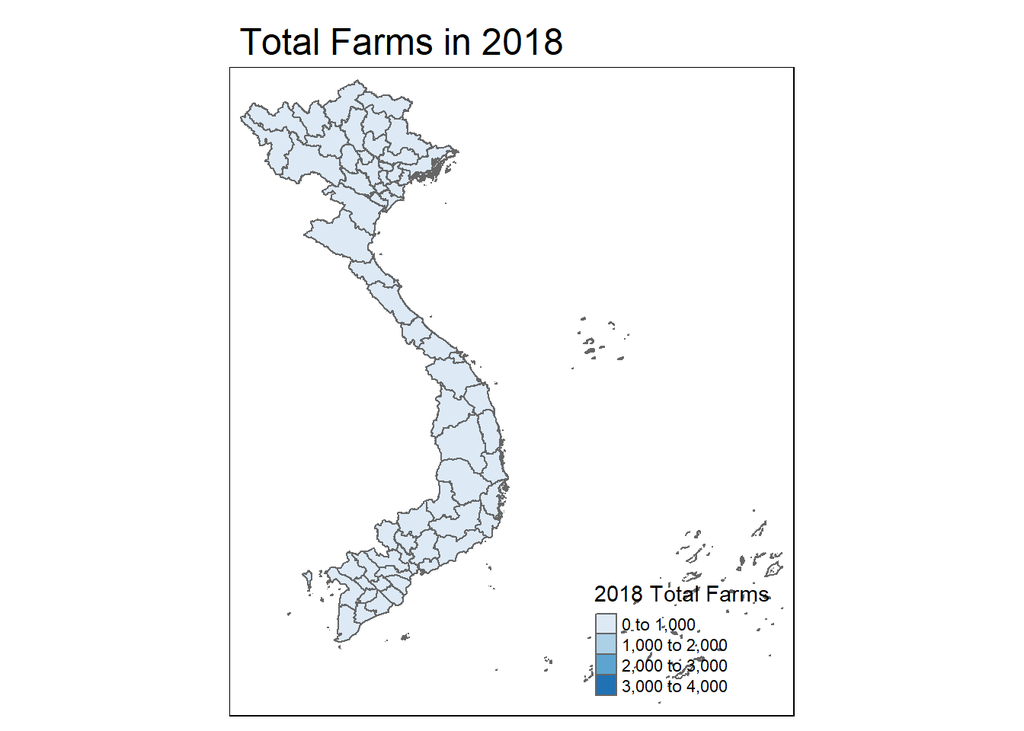

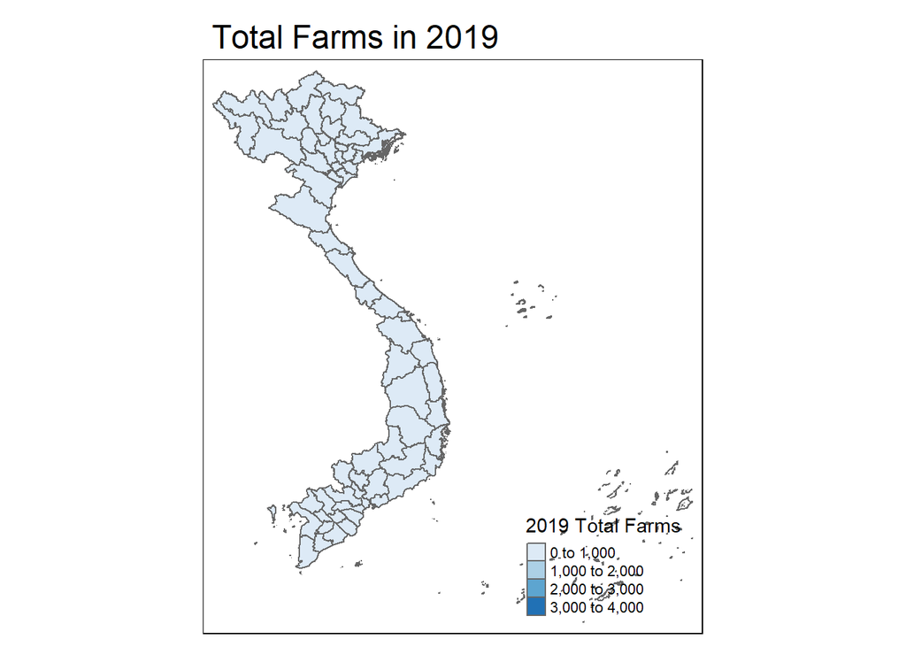

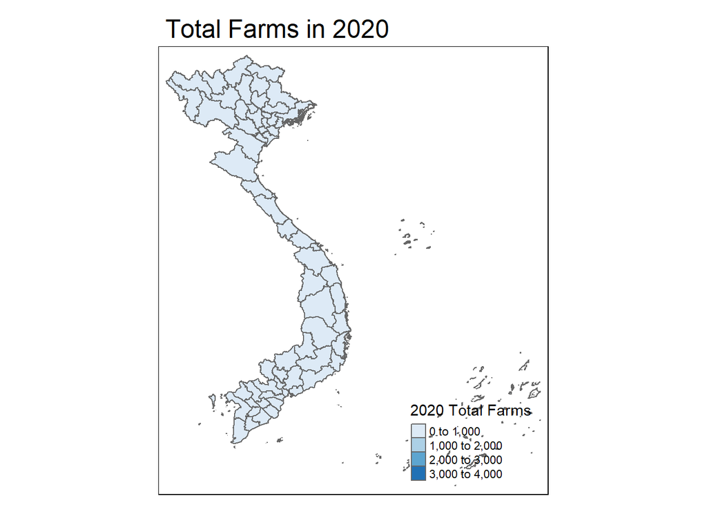

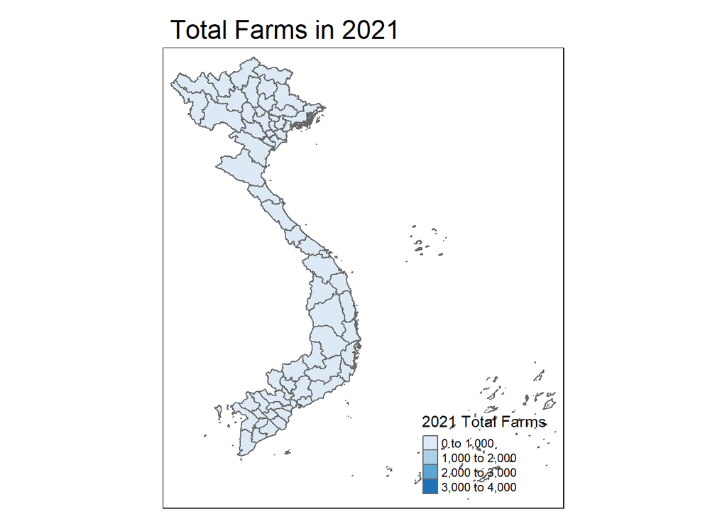

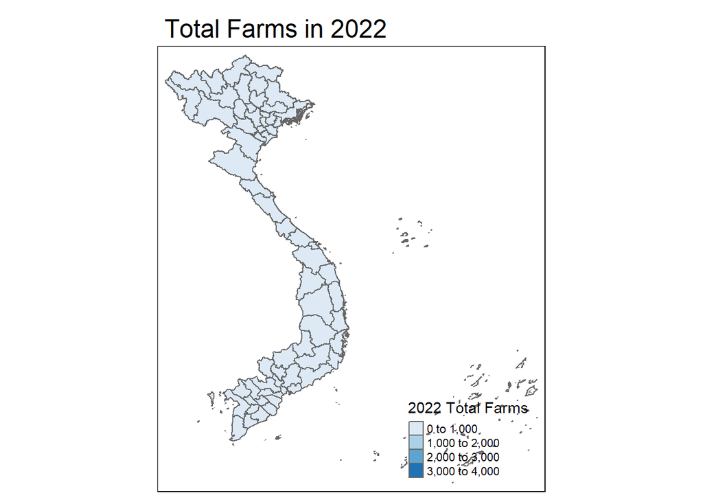

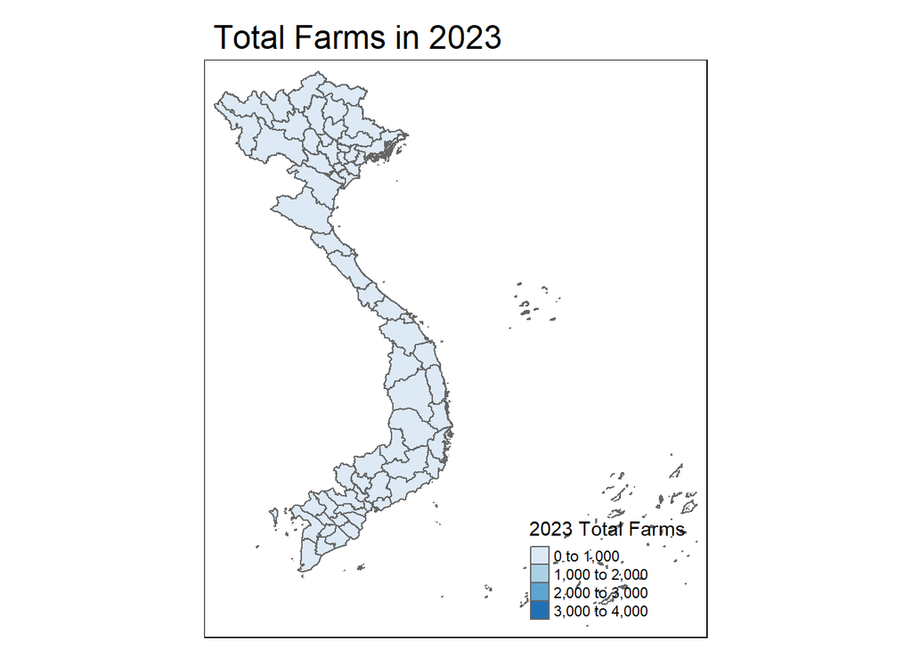

```r
for (year in 2012:2023) {
  map_year <- vietnam_eda_data %>%
    left_join(farms_long %>% filter(year_type == paste(year, "Total")), by = "province_name")

  print(
    tm_shape(map_year) +
      tm_polygons("count.x", title = paste(year, "Total Farms"), palette = "Blues") +
      tm_layout(main.title = paste("Total Farms in", year), legend.position = c("right", "bottom"))
  )
}
```

### 8.0.1 **Summary and Interpretation**

Upon completing the Spatial Exploratory Data Analysis (EDA), we identified several key spatial patterns in farm distribution across Vietnamese provinces. These insights, derived through both global and local spatial autocorrelation methods, highlight the data’s underlying spatial structure and reveal areas of potential interest for agricultural development, policy-making, and investment.

**1. Global Autocorrelation (Moran’s I)**: The Global Moran’s I statistic assesses whether similar values in farm counts are clustered across provinces. While the positive value suggests slight clustering, the statistical significance is marginal, indicating only a minor tendency for spatial clustering. This suggests that while there is some level of clustering in farm distribution, it’s not dominant enough to make broad assumptions about uniform spatial patterns at a global scale.

**2. Local Clusters (LISA)**: Local Moran’s I (LISA) allows us to drill down to identify specific clusters and outliers. This granularity helps detect regional agricultural hubs (high-high clusters) and areas of low activity (low-low clusters), which may benefit from targeted interventions. By pinpointing both dense and sparse regions of farm activity, we gain insights that could drive location-specific strategies and resource allocation.

**3. Cluster Types**:

- **High-High (HH)**: Areas where high farm counts are surrounded by other high counts, often indicating economically significant agricultural hubs. These clusters could attract further investment or research to support efficient agricultural practices.
- **Low-Low (LL)**: Regions with consistently low farm activity may be under-resourced or lack suitable conditions for farming. These clusters present opportunities for development projects or support programs.
- **High-Low (HL) and Low-High (LH)**: These more complex clusters could indicate regions with unique agricultural characteristics, such as varying terrain, resources, or practices that affect productivity differently from their neighboring areas.

### 8.0.3 **Implications for Future Research and Development**

This analysis underscores the value of spatial EDA for informed decision-making, allowing stakeholders to base strategies on data-driven insights. The findings could be further refined through predictive modeling, using machine learning techniques to forecast growth areas or identify emerging clusters based on historical data.

By identifying these spatial patterns and observing trends over time, policymakers, investors, and stakeholders can leverage this knowledge to support targeted, region-specific initiatives for sustainable agricultural development in Vietnam.

# 9 Storyboarding

Storyboarding serves as an essential tool in this assignment for planning out the transformation of our Exploratory Spatial Data Analysis (ESDA) into an interactive Shiny application. By breaking down each step in the process—from data gathering and cleaning to visualisation and spatial analysis—storyboarding provides a clear, structured approach that guides us in designing each feature of the application.

In this storyboard, we outline how users will interact with the app, which tools and analyses they can access, and how we’ll use Shiny components to bring these functionalities to life. For instance, we start with data cleaning and visualisation, providing users a way to see the dataset and explore different farm types across years. Then, we move into spatial analysis, enabling users to perform both Global and Local Moran’s I calculations to understand clustering. Finally, we show how these components will be organised within Shiny, allowing users to interact with maps, adjust parameters, and view results dynamically.

**Why We Need Storyboarding**

Storyboarding is crucial because it helps us visualise the entire application flow before we start coding in Shiny. It ensures that each analytical component of ESDA is translated into an interactive feature, which will be intuitive for users. This planning process not only improves the app’s design and user experience but also helps us stay organised, ensuring that we meet the project requirements while providing a clear roadmap for development.

For a computer science student or professor, storyboarding is a valuable practice in project development, as it bridges the gap between analysis and application. It allows us to foresee any potential challenges and make strategic design decisions that enhance the application’s functionality and user interaction. This storyboard is a blueprint, helping us transform complex spatial analyses into accessible, interactive tools within Shiny.

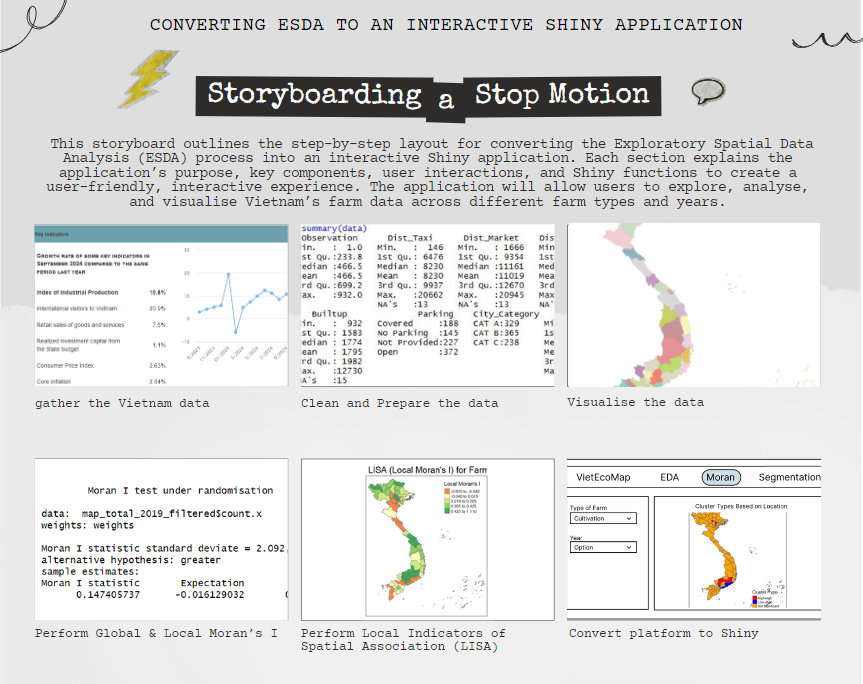

# 10 **References**

- General Statistics Office of Vietnam. (2022). *Achievements of the agriculture industry: A year summation.* Retrieved from https://www.gso.gov.vn/en/data-and-statistics/2022/03/achievements-of-the-agriculture-industry-a-year-summation/
- World Bank. (n.d.). *Agricultural land (% of land area) - Vietnam.* Retrieved October 2024, from https://data.worldbank.org/indicator/AG.LND.AGRI.ZS?locations=VN
- Statista. (2022). *Agriculture in Vietnam - statistics & facts.* Retrieved from https://www.statista.com/topics/5653/agriculture-in-vietnam/
- Anselin, L., Syabri, I., & Kho, Y. (2006). *GeoDa: An introduction to spatial data analysis.* Geographical Analysis, 38(1), 5-22. doi:10.1111/j.0016-7363.2005.00671.x
- Rey, S. J., & Anselin, L. (2007). *PySAL: A Python library of spatial analytical methods.* In Fischer, M. & Getis, A. (Eds.), *Handbook of Applied Spatial Analysis* (pp. 325-338). Springer. doi:10.1007/978-3-642-03647-7_13
- Cheng, J., Karambelkar, B., & Xie, Y. (2021). *Leaflet: Create interactive web maps with the JavaScript ‘Leaflet’ library.* R package version 2.0.4.1. Retrieved from https://cran.r-project.org/web/packages/leaflet/index.html
- Chang, W., & Borges Ribeiro, B. (2021). *Shiny: Web application framework for R.* R package version 1.7.1. Retrieved from https://cran.r-project.org/web/packages/shiny/index.html
- Bivand, R. S., Pebesma, E., & Gómez-Rubio, V. (2013). *Applied spatial data analysis with R* (2nd ed.). Springer. doi:10.1007/978-1-4614-7618-4